# Integrating Tropical Grassland Eddy Covariance Flux Data to Improve Grassland Gross Primary Production Estimates

Naoya Takeda, Liam Grace, David Rowlings, Peter Grace

2025-07-08

# 1 Introduction

Eddy Covariance (EC) flux towers allow direct, high-frequency measurements of land-atmosphere carbon (C) exchange, providing a unique opportunity to evaluate C cycle processes in terrestrial ecosystems.

In grasslands — one of the most expansive and productive biomes covering over 40% of the Earth’s land surface yet highly heterogeneous — EC observations offer valuable insight into gross primary productivity (GPP) and its variability across climatic gradients.

However, global GPP estimates and underpinning EC flux datasets remain heavily weighted toward temperate regions, leaving tropical grasslands underrepresented and introducing uncertainty into global C estimates.

This study synthesised EC flux data at ~20 grassland sites predominantly in the tropical regions in Australia with publicly available grassland EC flux datasets including FLUXNET 2015, AMERIFLUX and ICOS, together with meteorological and remote sensing data to improve GPP estimation.

# 2 Grassland EC flux tower locations

## 2.1 Global grassland EC towers

- Grassland map: WWF World Grassland Types 2014
- Across publicly available EC flux datasets (FLUXNET 2015, AMERIFLUX and ICOS), the majority of grassland flux datasets are from the northern hemisphere and temperate regions (61/67 sites).

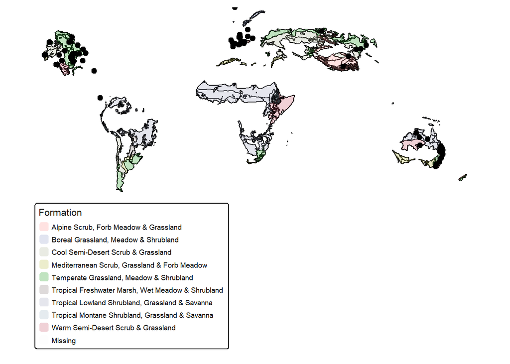

## 2.2 Australian grassland EC towers

- Australian Bioregions
- QUT has contributed 18/24 Grassland EC towers to those in Australia

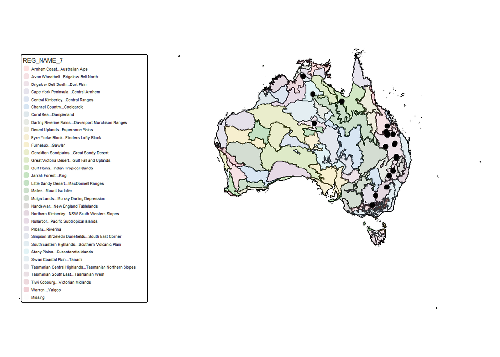

## 2.3 Latitudal distribution

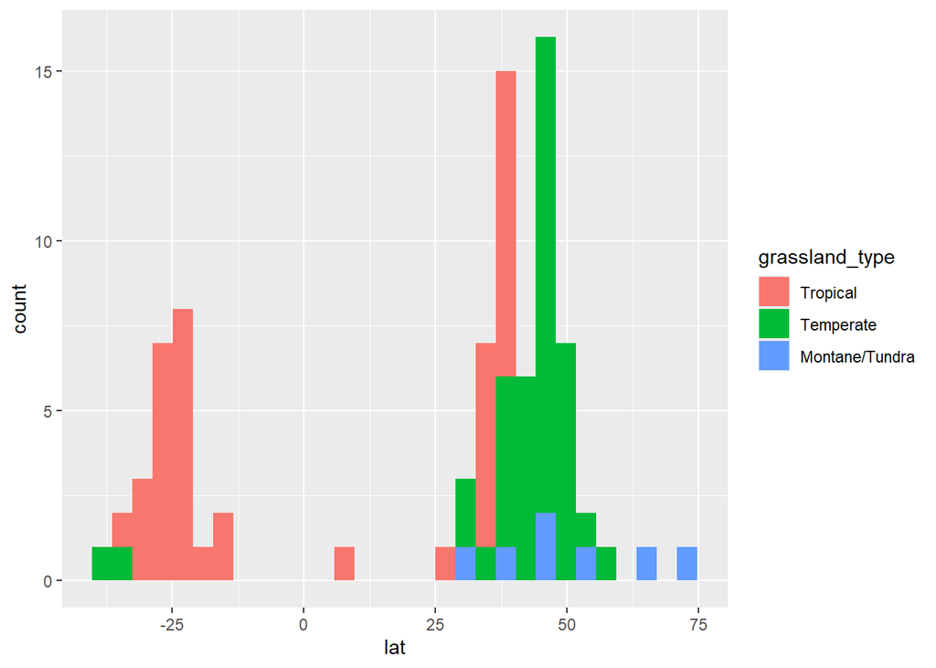

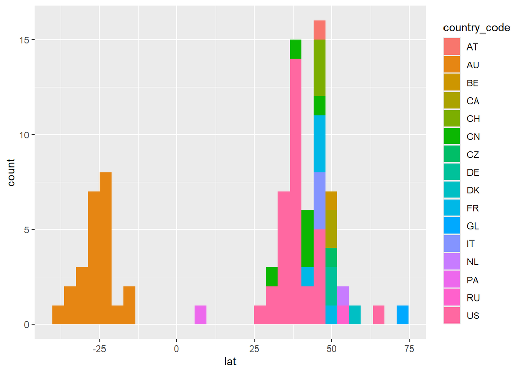

# 3 EC flux tower GPP data

## 3.1 Julian day

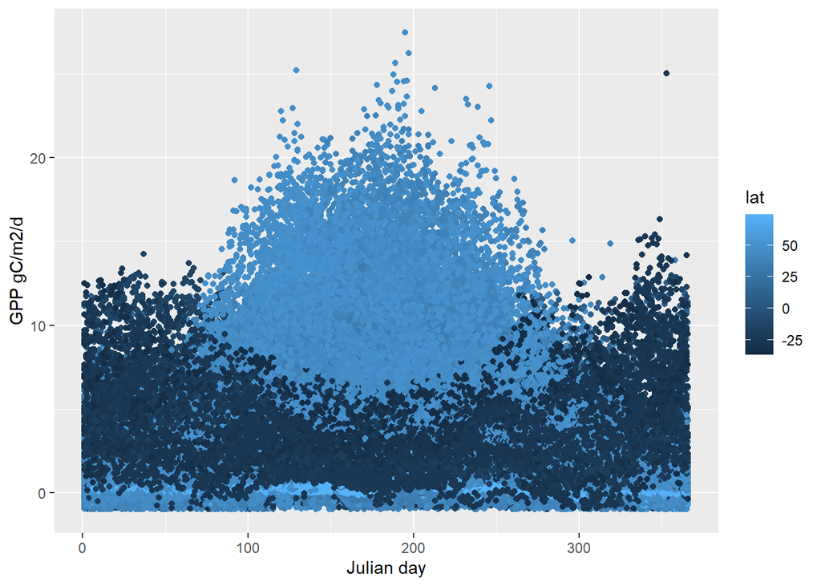

## 3.2 Temperature

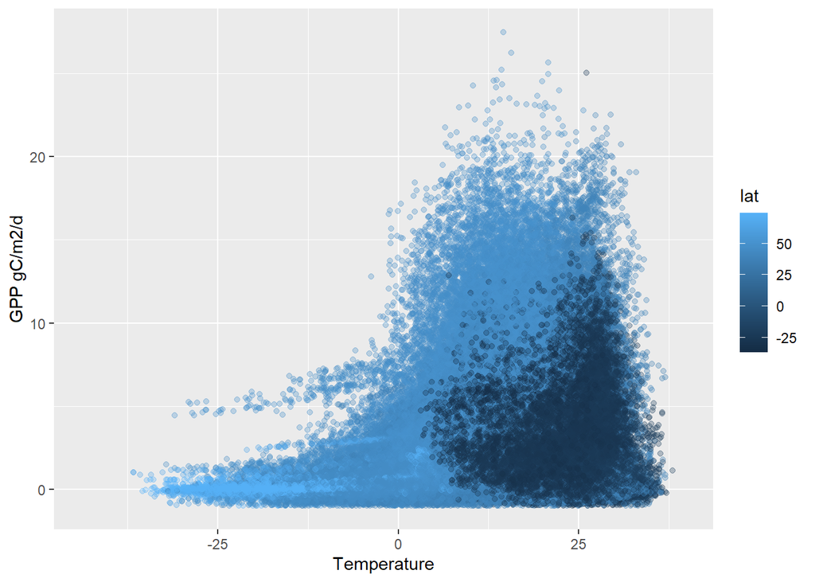

## 3.3 VPD

```
## [1] "Sourced from meteorology data"
```

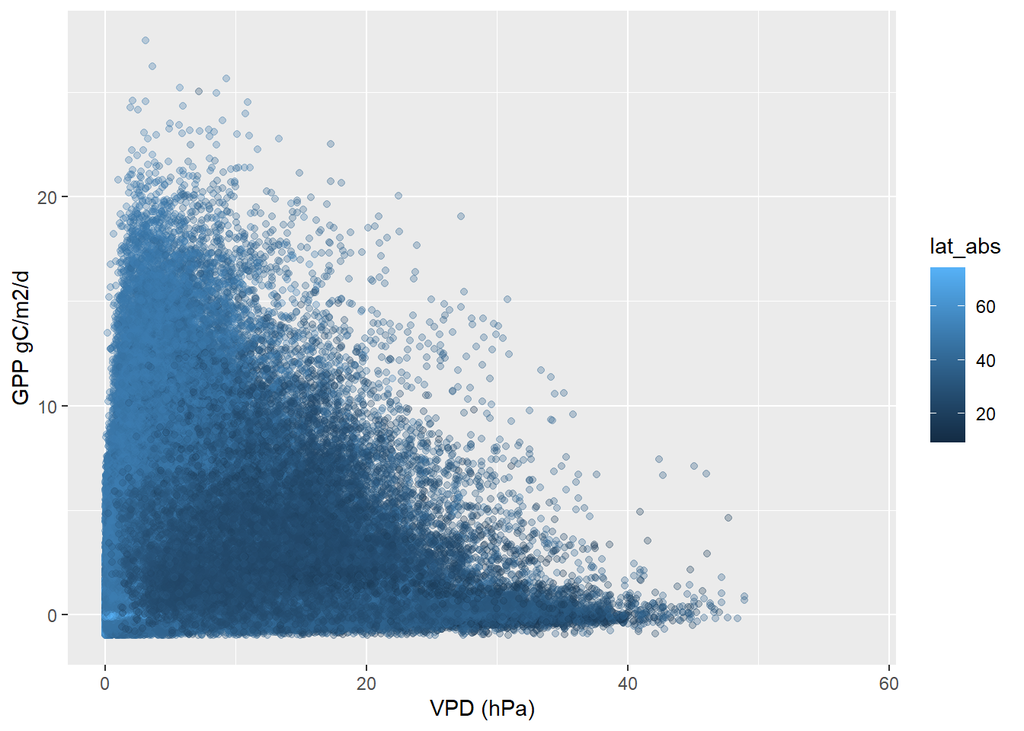

```
## [1] "Sourced from the flux tower"
```

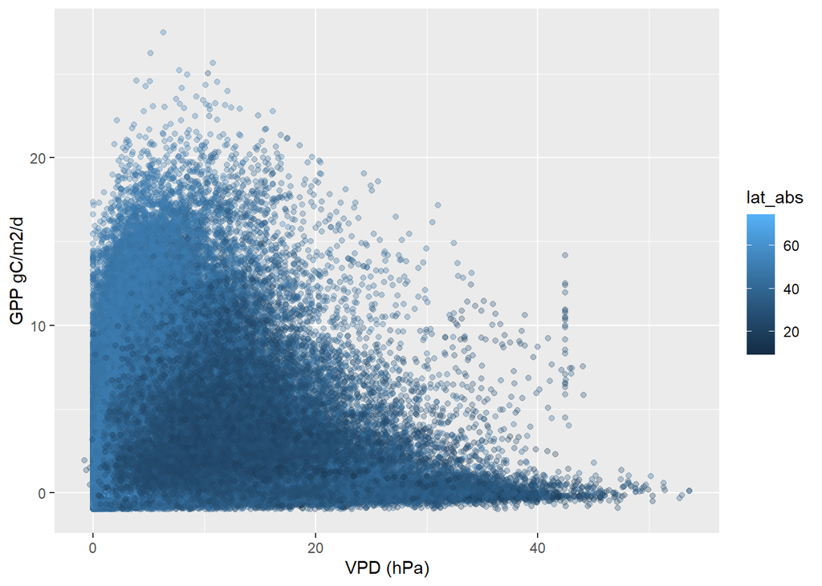

## 3.4 Radiation

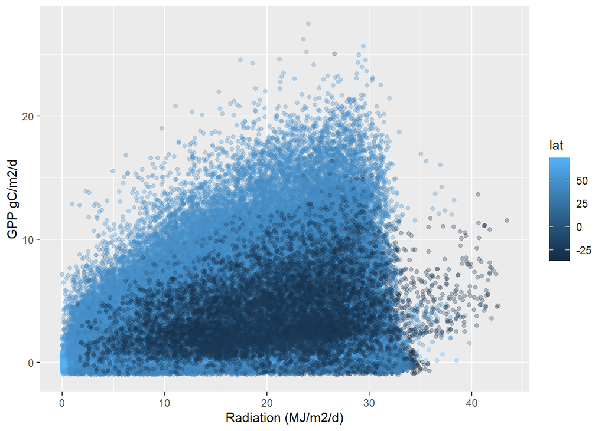

## 3.5 NDVI

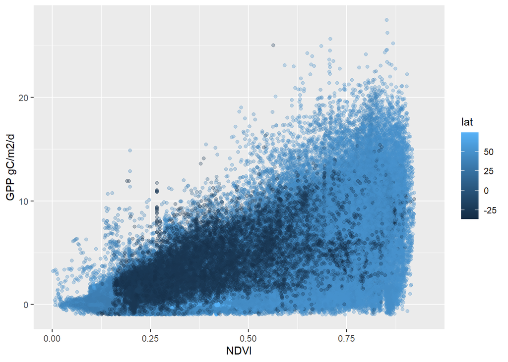

# 4 GPP modelling

## 4.1 MODIS GPP model (MOD17A2)

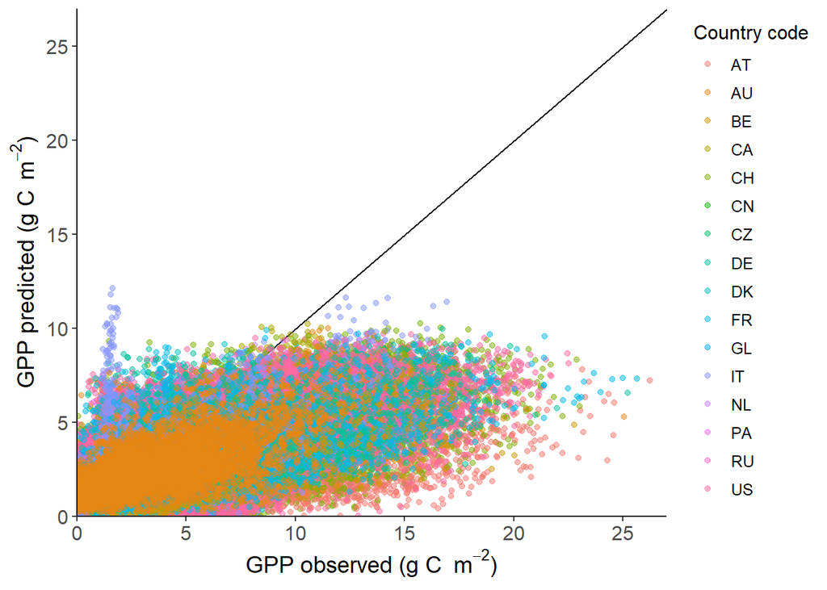

```
## [1] "R-squared"
```

```
## [1] 0.5944789
```

```
## [1] "RMSE (gC/m2)"
```

```
## [1] 2.782233
```

```
## [1] "RRMSE (%)"
```

```
## [1] 93.20144
```

```
## [1] "PBIAS (%)"
```

```
## [1] -37.49346
```

## 4.2 Site-specific parameterisation

- Using the 1st half of flux data at each site

  Parameter configuration

  | Parameter | Default value | Lower limit | Upper limit |
  | --- | --- | --- | --- |
  | lue_max | 0.86 | 0.5 | 3 |
  | tmin_min | -8.00 | -25.0 | 0 |
  | tmin_max | 12.02 | 5.0 | 30 |
  | vpd_min | 650.00 | 50.0 | 1000 |
  | vpd_max | 5300.00 | 1500.0 | 6500 |

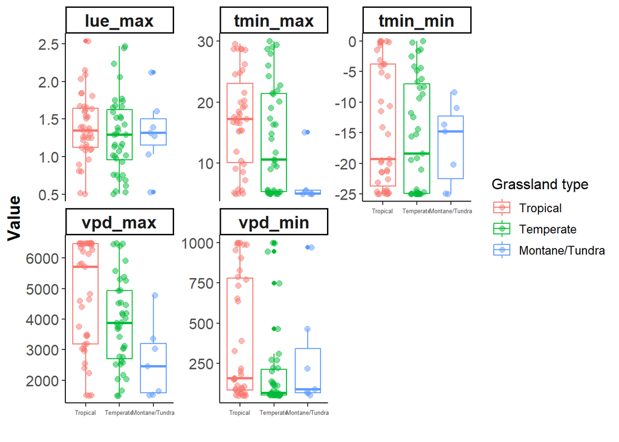

## 4.3 Site-specific parameter inference from MAP & MAT

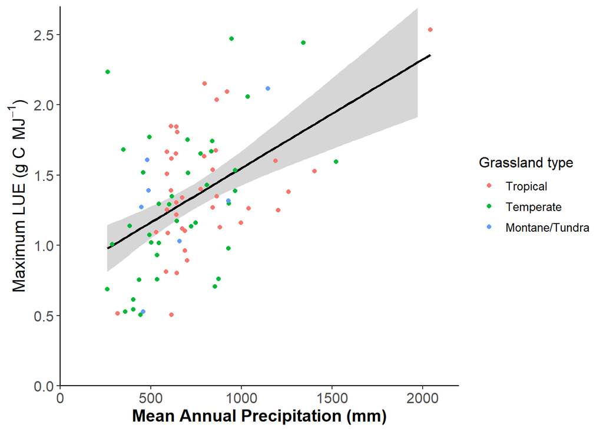

```
##
## Call:
## lm(formula = params_modis_map_all_meta_lue$lue_max ~ params_modis_map_all_meta_lue$map +
##     params_modis_map_all_meta_lue$mat)
##
## Residuals:
##      Min       1Q   Median       3Q      Max
## -0.79145 -0.31561 -0.07183  0.27491  1.24975
##
## Coefficients:
##                                    Estimate Std. Error t value Pr(>|t|)
## (Intercept)                       0.7263321  0.1346898   5.393 6.55e-07 ***
## params_modis_map_all_meta_lue$map 0.0007593  0.0001540   4.929 4.24e-06 ***
## params_modis_map_all_meta_lue$mat 0.0047098  0.0058168   0.810     0.42
## ---
## Signif. codes:  0 '***' 0.001 '**' 0.01 '*' 0.05 '.' 0.1 ' ' 1
##
## Residual standard error: 0.4146 on 82 degrees of freedom
## Multiple R-squared:  0.2424, Adjusted R-squared:  0.2239
## F-statistic: 13.12 on 2 and 82 DF,  p-value: 1.142e-05
```

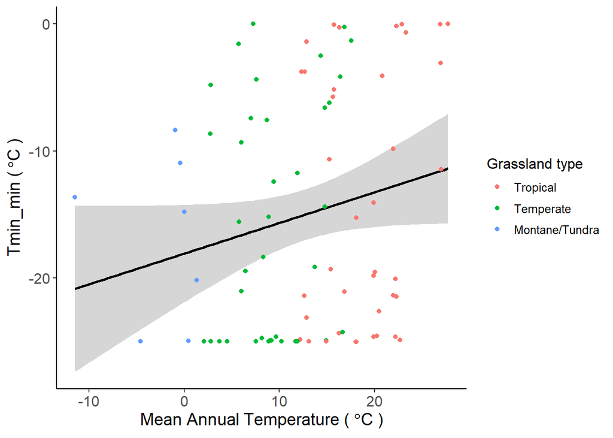

```
##
## Call:
## lm(formula = params_modis_map_all_meta_lue$tmin_min ~ params_modis_map_all_meta_lue$map +
##     params_modis_map_all_meta_lue$mat)
##
## Residuals:
##     Min      1Q  Median      3Q     Max
## -12.402  -8.726  -2.361   8.886  16.275
##
## Coefficients:
##                                     Estimate Std. Error t value Pr(>|t|)
## (Intercept)                       -1.828e+01  3.020e+00  -6.052  4.1e-08 ***
## params_modis_map_all_meta_lue$map  3.067e-04  3.454e-03   0.089   0.9295
## params_modis_map_all_meta_lue$mat  2.398e-01  1.304e-01   1.838   0.0697 .
## ---
## Signif. codes:  0 '***' 0.001 '**' 0.01 '*' 0.05 '.' 0.1 ' ' 1
##
## Residual standard error: 9.298 on 82 degrees of freedom
## Multiple R-squared:  0.04061,    Adjusted R-squared:  0.01721
## F-statistic: 1.736 on 2 and 82 DF,  p-value: 0.1827
```

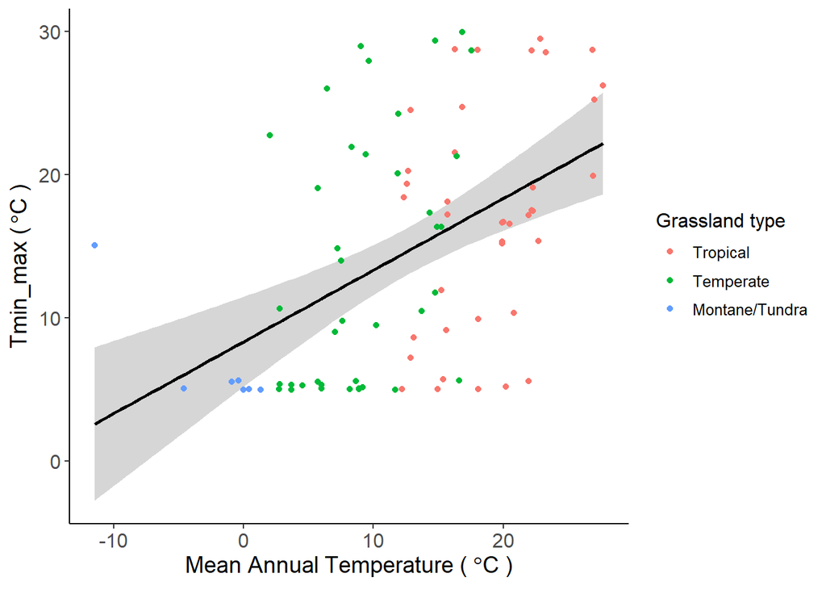

```
##
## Call:
## lm(formula = params_modis_map_all_meta_lue$tmin_max ~ params_modis_map_all_meta_lue$map +
##     params_modis_map_all_meta_lue$mat)
##
## Residuals:
##     Min      1Q  Median      3Q     Max
## -13.764  -5.416  -2.045   5.647  16.076
##
## Coefficients:
##                                     Estimate Std. Error t value Pr(>|t|)
## (Intercept)                        8.4720202  2.4841975   3.410  0.00101 **
## params_modis_map_all_meta_lue$map -0.0001886  0.0028410  -0.066  0.94724
## params_modis_map_all_meta_lue$mat  0.5012317  0.1072832   4.672 1.15e-05 ***
## ---
## Signif. codes:  0 '***' 0.001 '**' 0.01 '*' 0.05 '.' 0.1 ' ' 1
##
## Residual standard error: 7.648 on 82 degrees of freedom
## Multiple R-squared:  0.212,  Adjusted R-squared:  0.1928
## F-statistic: 11.03 on 2 and 82 DF,  p-value: 5.729e-05
```

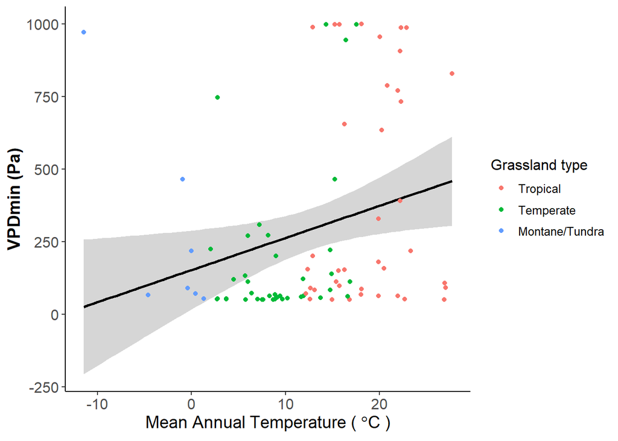

```
##
## Call:
## lm(formula = params_modis_map_all_meta_lue$vpd_min ~ params_modis_map_all_meta_lue$map +
##     params_modis_map_all_meta_lue$mat)
##
## Residuals:
##    Min     1Q Median     3Q    Max
## -407.9 -213.2 -111.6  130.1  892.8
##
## Coefficients:
##                                   Estimate Std. Error t value Pr(>|t|)
## (Intercept)                       371.2374   102.6606   3.616 0.000515 ***
## params_modis_map_all_meta_lue$map  -0.3260     0.1174  -2.777 0.006800 **
## params_modis_map_all_meta_lue$mat  12.4928     4.4335   2.818 0.006058 **
## ---
## Signif. codes:  0 '***' 0.001 '**' 0.01 '*' 0.05 '.' 0.1 ' ' 1
##
## Residual standard error: 316 on 82 degrees of freedom
## Multiple R-squared:  0.146,  Adjusted R-squared:  0.1252
## F-statistic: 7.011 on 2 and 82 DF,  p-value: 0.001545
```

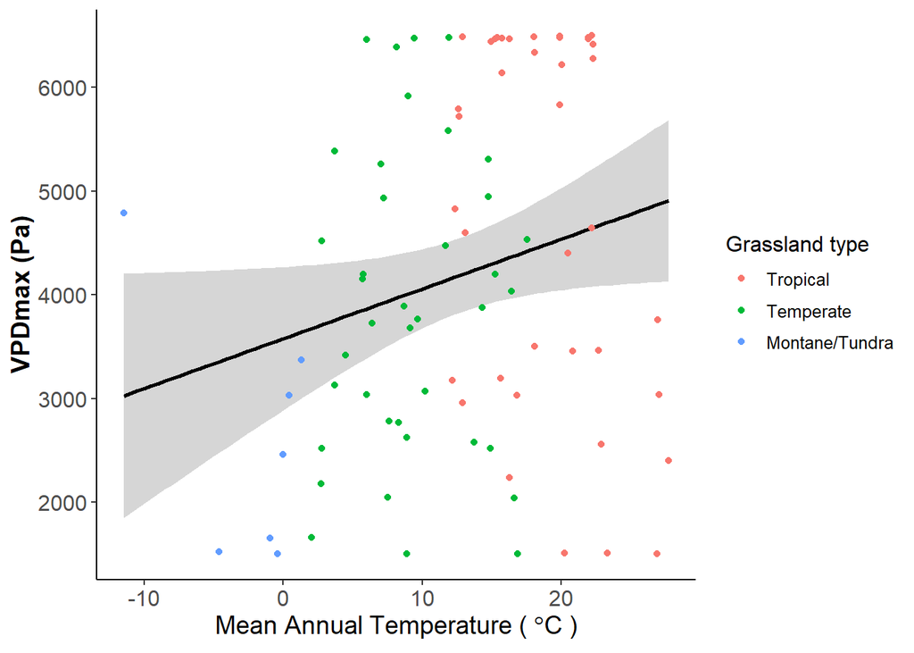

```
##
## Call:
## lm(formula = params_modis_map_all_meta_lue$vpd_max ~ params_modis_map_all_meta_lue$map +
##     params_modis_map_all_meta_lue$mat)
##
## Residuals:
##     Min      1Q  Median      3Q     Max
## -3713.4 -1091.0  -178.4  1609.4  2734.8
##
## Coefficients:
##                                    Estimate Std. Error t value Pr(>|t|)
## (Intercept)                       4354.6058   533.7249   8.159 3.38e-12 ***
## params_modis_map_all_meta_lue$map   -1.1574     0.6104  -1.896   0.0615 .
## params_modis_map_all_meta_lue$mat   53.1182    23.0496   2.305   0.0237 *
## ---
## Signif. codes:  0 '***' 0.001 '**' 0.01 '*' 0.05 '.' 0.1 ' ' 1
##
## Residual standard error: 1643 on 82 degrees of freedom
## Multiple R-squared:  0.08888,    Adjusted R-squared:  0.06666
## F-statistic:     4 on 2 and 82 DF,  p-value: 0.02201
```

## 4.4 Validation (daily)

- Using the 2nd half of flux data at each site

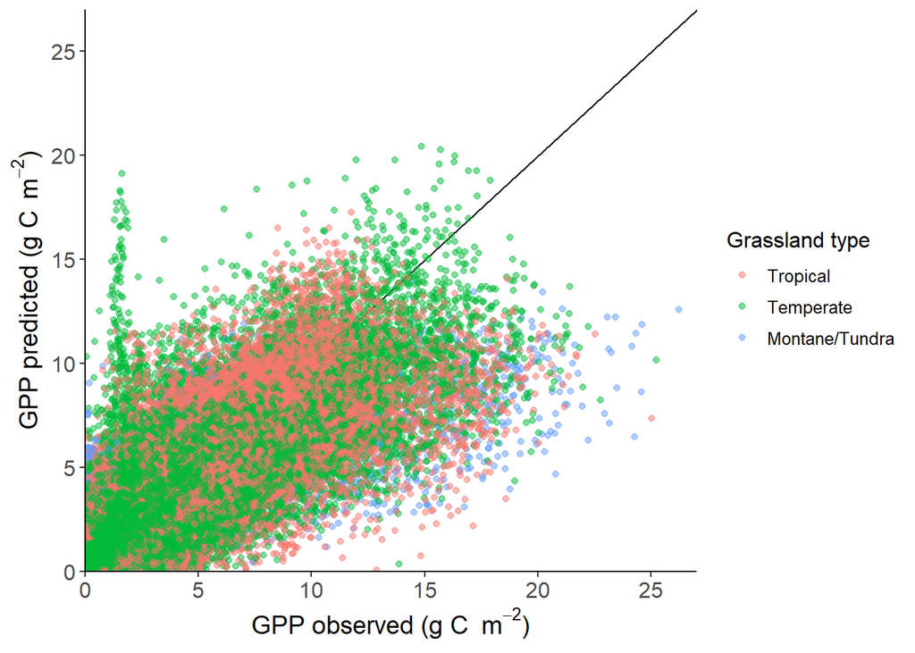

```
## [1] "R-squared"
```

```
## [1] 0.652315
```

```
## [1] "RMSE (gC/m2)"
```

```
## [1] 2.252509
```

```
## [1] "RRMSE (%)"
```

```
## [1] 74.74779
```

```
## [1] "PBIAS (%)"
```

```
## [1] -2.791108
```

## 4.5 Validation (annual)

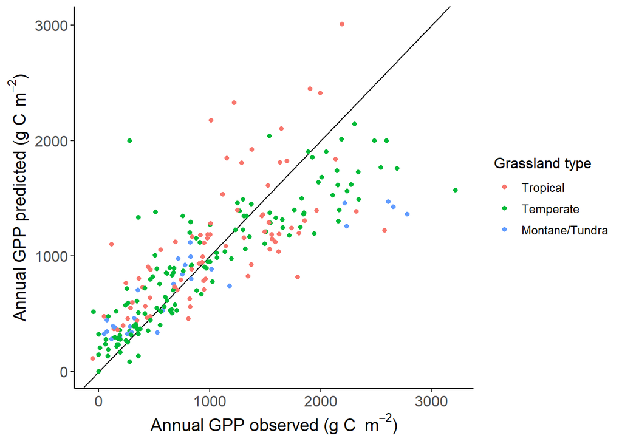

```
## [1] "R-squared"
```

```
## [1] 0.6823992
```

```
## [1] "RMSE (gC/m2)"
```

```
## [1] 415.3279
```

```
## [1] "RRMSE (%)"
```

```
## [1] 44.88988
```

```
## [1] "PBIAS (%)"
```

```
## [1] -1.753
```

# 5 Materials and Methods

- Datasets:
  - The EC flux datasets included (i) 18 sites predominantly in the tropical grasslands in Australia run by QUT and (ii) publicly available 67 grassland EC sites from FLUXNET 2015, AMERIFLUX and ICOS (Figure 1)
  - The EC flux sites were classified into tropical (Aw, Am, BSh, BWh, Cwa, Cfa), temperate (BSk, Cfb, Cfc, Csa, Dfa, Dfb, Dwa, Dwb) and montane/tundra (Dfc, ET) grasslands based on Köppen climate classification codes
  - The covariates included (i) meteorological data (maximum and minimum temperatures, radiation and vapor pressure deficit) retrieved from NASAPower and (ii) Landsat NDVI data processed using R package “LandsatTS”
- The MODIS GPP model (MOD17A2) was tested across the collated grassland sites with the default grassland parameters (i.e. lue_max = 0.86 g C MJ-1, tmin_max = 12.02 °C, tmin_min = -8.0 °C, vpd_max = 5300 Pa, vpd_min = 650 Pa)
- The model parameters were site-specifically calibrated using the first half of the EC GPP data and the Markov Chain Monte Carlo (MCMC) method
- The site-specifically calibrated parameters were inferred from the mean annual precipitation (MAP, mm) and mean annual temperature (MAT, °C) using linear regressions
- The GPP model with inferred parameters were validated across the collated grassland sites using the second half of the EC GPP data

# 6 Contact

For inquiries or collaborations, feel free to email me or connect via [GitHub](https://github.com/tkd708/fluxnet_2025/issues) - the GitHub Issues page allows open discussion.

# 7 References

- Huang, X., Xiao, J., Wang, X., & Ma, M. (2021). Improving the global MODIS GPP model by optimizing parameters with FLUXNET data. Agricultural and Forest Meteorology, 300, 108314. https://doi.org/10.1016/j.agrformet.2020.108314
- Robinson, N. P., Allred, B. W., Smith, W. K., Jones, M. O., Moreno, A., Erickson, T. A., Naugle, D. E., & Running, S. W. (2018). Terrestrial primary production for the conterminous United States derived from Landsat 30 m and MODIS 250 m. Remote Sensing in Ecology and Conservation, 4(3), 264–280. https://doi.org/10.1002/rse2.74
- Zhu, X., Pei, Y., Zheng, Z., Dong, J., Zhang, Y., Wang, J., Chen, L., Doughty, R. B., Zhang, G., & Xiao, X. (2018). Underestimates of Grassland Gross Primary Production in MODIS Standard Products. Remote Sensing, 10(11), Article 11. https://doi.org/10.3390/rs10111771